# KU AI Workshop

## Learning Machine Learning - Gradient Descent

### By: Daniel Johnson

# Problem Description

### Given a set of parameters, minimize some function over these parameters.

# What is Gradient Descent?

### Nerd Definition: Gradient descent is a first-order iterative optimization algorithm for finding a local minimum of a differentiable function.

### - Wikipedia

### **BUT HEAR ME OUT**

### A Simpler Definition:

### Think of a function as a hill. Walk down the hill by taking the steepest step at any point.

### Why?

### There are applications over many fields for optimization.

[figure not shown]

### Today, I will be focusing Gradient Descent in terms of machine learning.

### In machine learning, Gradient Descent is used in Linear/Logistic Regression, (Linear) Support Vector Machines, Neural Networks, etc. All of these algorithms have parameters that need to be optimized.

# ML Recap

### Remember, supervised learning is all about learning from labeled data.

That is, we have a dataset consisting of feature vectors ($x$) and outputs ($y$), $$ x = \left[ \begin{array}{ccc} x_1 & x_2 & x_3 & ... & x_n \end{array}\right],\ \ y $$

So, we may have a data point at $x = 5,\ y = 3(5) + 5 + 0.5 = 20.5$

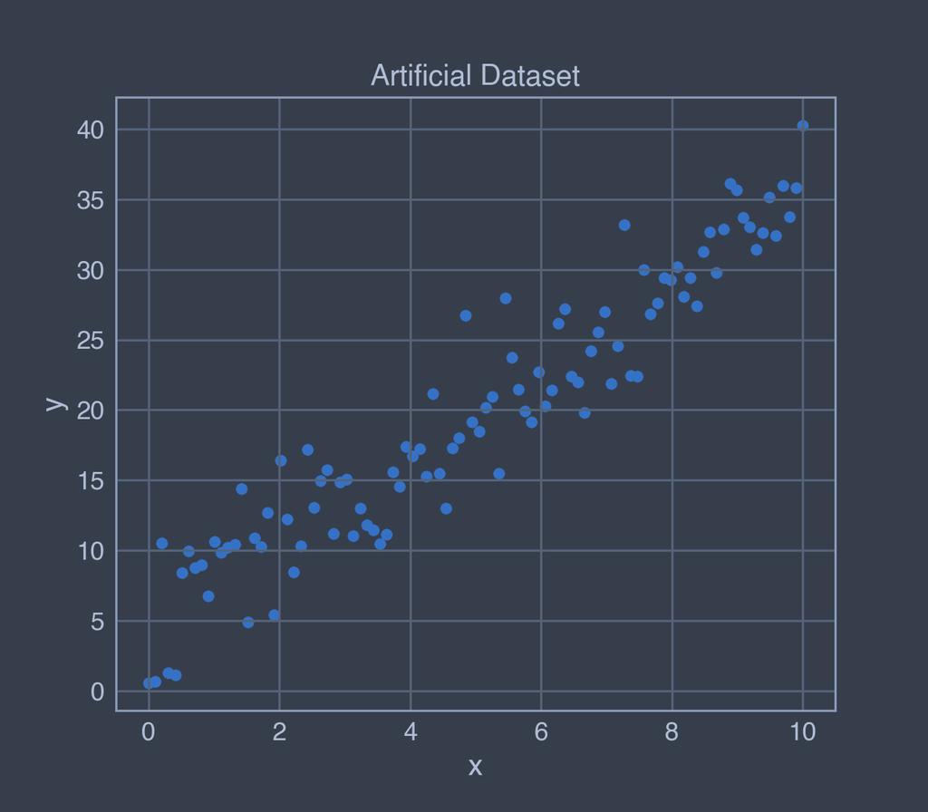

```python
# show the dataset
display(Image(filename='imgs/random_data.png', retina=True))
```

# Application: Linear Regression

We will be implementing gradient descent in the simple case of **linear regression**.

The idea of linear regression is that we want to form a "best fit" line to our data, good old $ y = mx + b $.

So, the goal is to find the best $m$ and $b$. We will generalize these parameters to $$ \theta = [\theta _0\ \theta _1] $$

Using this $\theta$, we can make predictions by simply feeding an input $x$ into $$ prediction(x) = \theta _0 x + \theta _1 $$

This begs the question, what makes a *bad* $\theta$?

We use a **cost function**, sometimes represented as $J(\theta)$.

There are many cost functions out there, some of which you can find at [this tensorflow docs page](https://www.tensorflow.org/api_docs/python/tf/keras/losses). We will use Mean Squared Error (MSE), which is very fit for regression.

$$ J(\theta) = \frac{1}{n}\sum_{i=1}^{n}(y_{real} - y_{predicted})^2 $$

So, our formal goal is $$argmin_{\theta}(J(\theta))$$

This is somewhat arbitrary, but randomness helps finding better local minima over many runs.

Let's see how we've done before training.

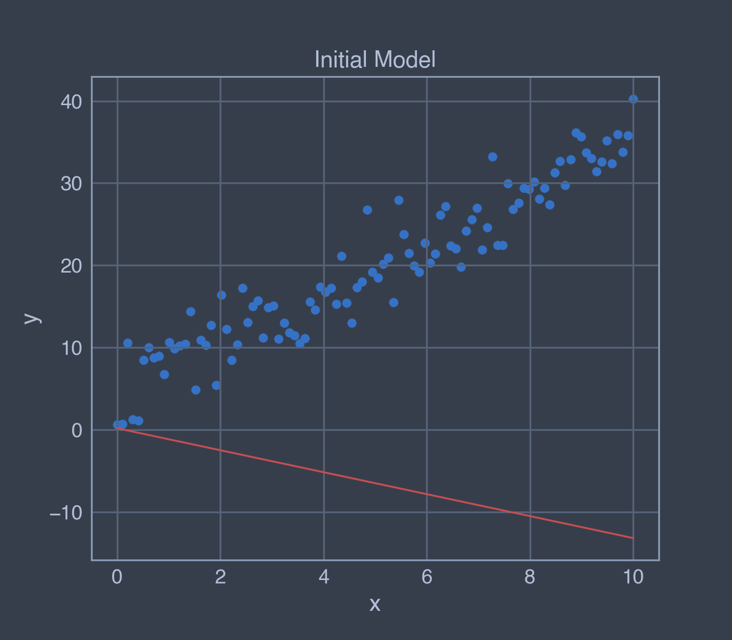

```python
display(Image(filename='imgs/initial_model.png', retina=True))
```

Untrained $\theta$ doesn't work very well, so how to we minimize $J(\theta)$?

# Gradient Descent (Math Cheat Code)

Gradient Descent is like walking down a hill. You are at a point on a slope, and you go down. Very simple!

Using this, we can take "steps" down our cost function. How do you know which way is downhill? *Calculus*

If we take the derivative of our cost function with respect to $\theta$, we can take a "step" in the downwards direction. I won't bore you with the derivation, in fact I have something that will do it for us! Do this many times, and you got Gradient Descent.

[figure not shown]

credit: [Analytics Vidhya](https://www.analyticsvidhya.com/blog/2021/07/understanding-the-what-and-why-of-gradient-descent/)

But what is this "step"?

We want to adjust $\theta$ by some factor of the slope at your given point. We call this factor the "learning rate", which can be denoted as $\alpha$.

So, we update $\theta$ every iteration like so:

$$ \theta = \theta - \alpha * \frac{\partial J}{\partial \theta} $$

The learning rate is a parameter that can be manually fine tuned, these are called *hyperparameters*. Common values are $0.00001 \le \alpha \le 0.5$. Too small of $\alpha$ might take too long to converge, too large of $\alpha$ might actually diverge.

# Code Time :)

```python
# math is hard, good code is easy :)
# jax allows for easy differentiation
import jax.numpy as jnp
from jax import grad

def mse(ys_true: list[float], ys_pred: list[float]) -> float:
    return jnp.mean(((ys_true - ys_pred) ** 2))

mse_grad = grad(mse)
```

Our cost function will not look like the previous example, why?

J($\theta$) is a function that takes len($\theta$) = 2 inputs and gives one scaler output. 3D!

### Let's see it!

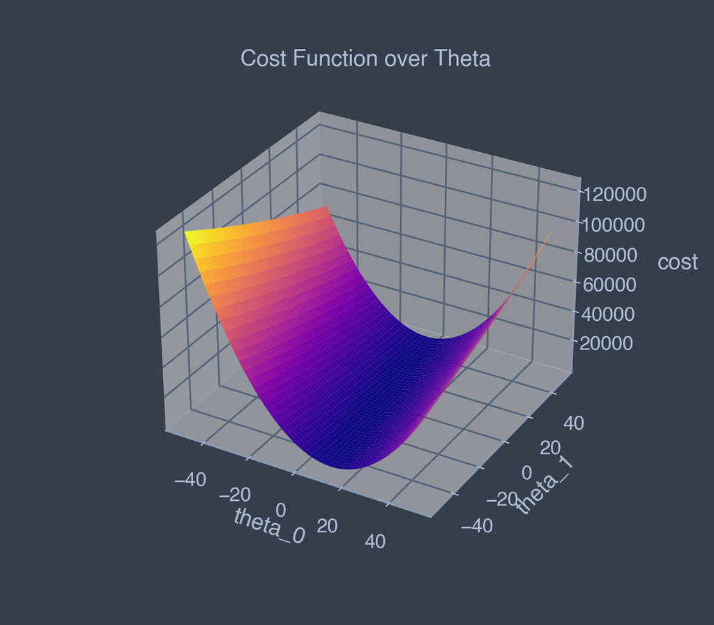

```python
display(Image(filename='imgs/cost_function.png', retina=True))
```

# Let's Train!

```python
# it is best practice to split your data into training and testing data
# this is because we want our model to generalize well to new data
# this way, we can use a training set to train our model,
#   and then evaluate the model on a test set
from sklearn.model_selection import train_test_split

MAX_ITER = 100
LEARNING_RATE = 0.01 # alpha

X_train, X_test, y_train, y_test = train_test_split(xs, ys, test_size=0.5, random_state=42)

cost_history_train = []
cost_history_test = []
theta_history = [theta]
for i in range(1, MAX_ITER + 1):
    y_pred_train = theta[0] * X_train + theta[1]
    mse_train = mse(y_train, y_pred_train)
    cost_history_train.append(mse_train)

    grad_mse_wrt_theta = -sum(mse_grad(y_train, y_pred_train))
    theta = theta - LEARNING_RATE * grad_mse_wrt_theta
    theta_history.append(theta)

    y_pred_test = theta[0] * X_test + theta[1]
    mse_test = mse(y_test, y_pred_test)
    cost_history_test.append(mse_test)

    print(f'Iteration {i}: MSE train = {mse_train:.3f}, test = {mse_test:.3f}')
```

```
Iteration 1: MSE train = 983.438, test = 559.894
Iteration 2: MSE train = 747.798, test = 422.219
Iteration 3: MSE train = 568.985, test = 318.337
Iteration 4: MSE train = 433.313, test = 240.034
Iteration 5: MSE train = 330.391, test = 181.081
Iteration 6: MSE train = 252.326, test = 136.759
Iteration 7: MSE train = 193.128, test = 103.491
Iteration 8: MSE train = 148.248, test = 78.569
Iteration 9: MSE train = 114.232, test = 59.940
Iteration 10: MSE train = 88.458, test = 46.053
Iteration 11: MSE train = 68.937, test = 35.734
Iteration 12: MSE train = 54.158, test = 28.096
Iteration 13: MSE train = 42.974, test = 22.468
Iteration 14: MSE train = 34.516, test = 18.345
Iteration 15: MSE train = 28.123, test = 15.345
Iteration 16: MSE train = 23.295, test = 13.182
Iteration 17: MSE train = 19.652, test = 11.639
Iteration 18: MSE train = 16.906, test = 10.554
Iteration 19: MSE train = 14.839, test = 9.806
Iteration 20: MSE train = 13.285, test = 9.305
Iteration 21: MSE train = 12.118, test = 8.981
Iteration 22: MSE train = 11.244, test = 8.786
Iteration 23: MSE train = 10.590, test = 8.682
Iteration 24: MSE train = 10.103, test = 8.641
Iteration 25: MSE train = 9.741, test = 8.643
Iteration 26: MSE train = 9.473, test = 8.674
Iteration 27: MSE train = 9.276, test = 8.723
Iteration 28: MSE train = 9.131, test = 8.782
Iteration 29: MSE train = 9.026, test = 8.846
Iteration 30: MSE train = 8.950, test = 8.911
Iteration 31: MSE train = 8.896, test = 8.976
Iteration 32: MSE train = 8.858, test = 9.037
Iteration 33: MSE train = 8.831, test = 9.095
Iteration 34: MSE train = 8.814, test = 9.149
Iteration 35: MSE train = 8.802, test = 9.198
Iteration 36: MSE train = 8.796, test = 9.243
Iteration 37: MSE train = 8.792, test = 9.283
Iteration 38: MSE train = 8.790, test = 9.319
Iteration 39: MSE train = 8.791, test = 9.352
Iteration 40: MSE train = 8.792, test = 9.381
```

[output cut: 45 more lines]

```
Iteration 86: MSE train = 8.824, test = 9.591
Iteration 87: MSE train = 8.824, test = 9.591
Iteration 88: MSE train = 8.824, test = 9.591
Iteration 89: MSE train = 8.824, test = 9.591
Iteration 90: MSE train = 8.824, test = 9.591
Iteration 91: MSE train = 8.824, test = 9.591
Iteration 92: MSE train = 8.824, test = 9.591
Iteration 93: MSE train = 8.824, test = 9.591
Iteration 94: MSE train = 8.824, test = 9.591
Iteration 95: MSE train = 8.824, test = 9.591
Iteration 96: MSE train = 8.824, test = 9.591
Iteration 97: MSE train = 8.824, test = 9.591
Iteration 98: MSE train = 8.824, test = 9.591
Iteration 99: MSE train = 8.824, test = 9.591
Iteration 100: MSE train = 8.824, test = 9.591
```

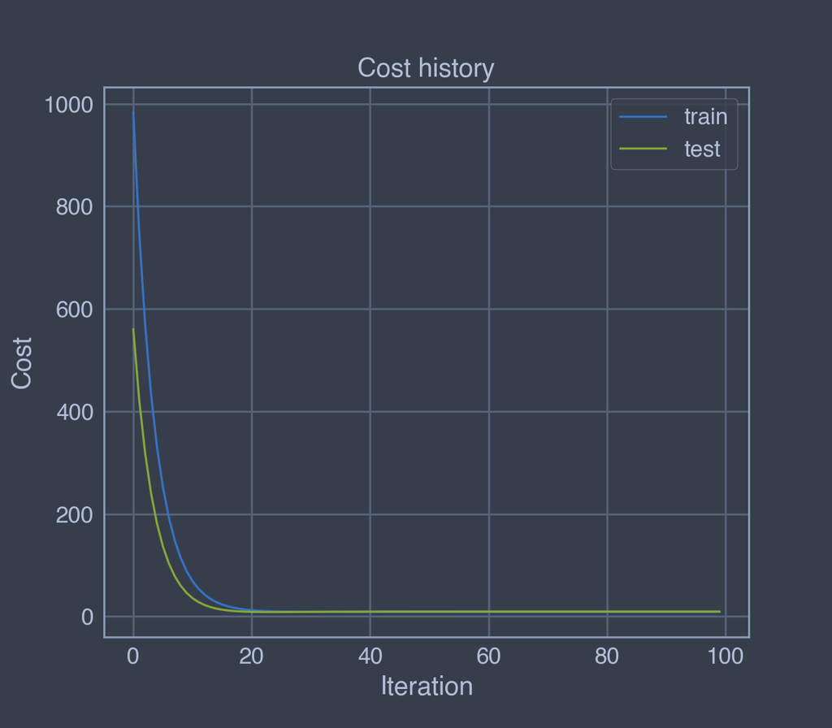

```python
display(Image(filename='imgs/cost_history.png', retina=True))
```

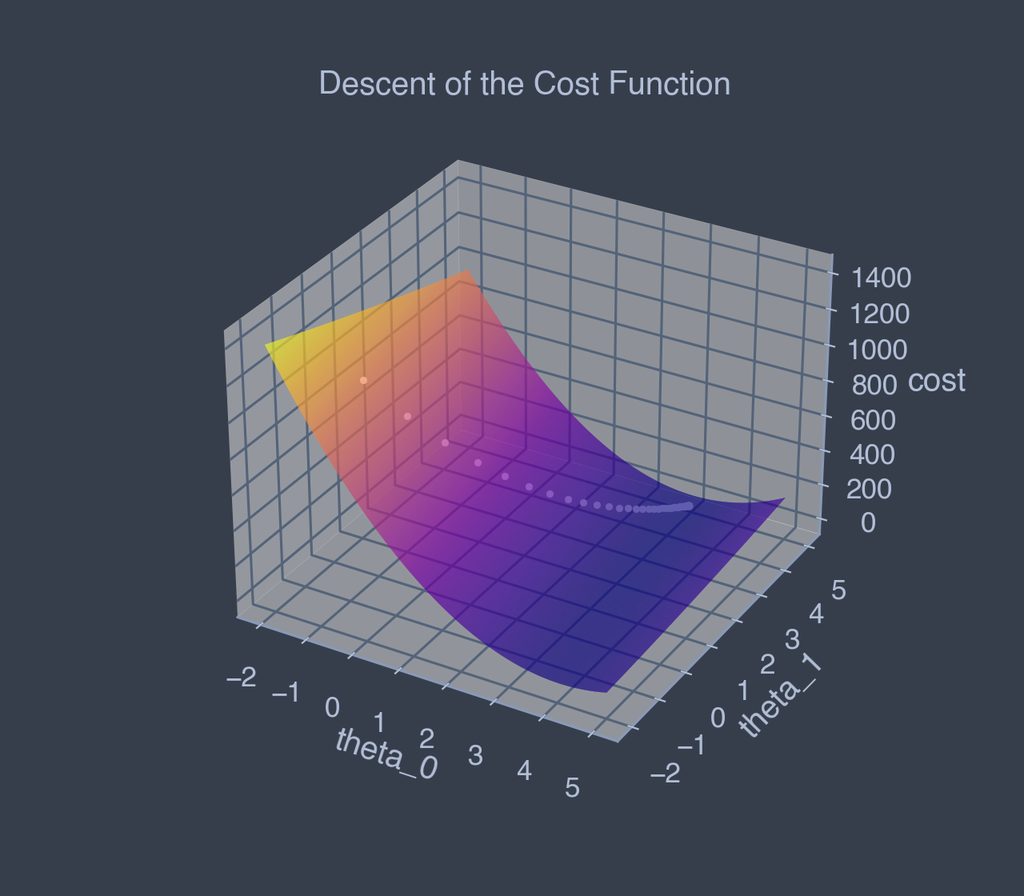

```python
display(Image(filename='imgs/cost_function_descent.png', retina=True))
```

```python
display(Image(filename='imgs/training_animation.gif', retina=True))
```

[output not shown]

# Questions?

## You can reach me at danielrjohnson00@ku.edu or through the KU AI Discord